# Dragon Ball Dataset

## Problem Definition

In the Dragon Ball universe, characters are defined by a wide range of attributes—from power levels and transformation abilities to battle experience and unique techniques. Despite the popularity of the series, there is no quantitative understanding of how these characteristics interact to influence outcomes such as fight results, power progression, and technique effectiveness. This project addresses the problem of extracting meaningful patterns from character data so that we can predict battle outcomes, estimate power levels, and ultimately provide tailored recommendations for character development.

### Objective

Discover Key Patterns:

- Identify the most influential features (like power level, transformation, race, and battle history) that correlate with different outcomes.

Inform Model Selection:

- Provide insights into which machine learning techniques might be best suited for tasks such as binary classification (win/loss prediction), continuous prediction (power level estimation), and unsupervised grouping (character archetypes).

Assess Data Quality:

- Evaluate the completeness, distribution, and potential biases in the dataset (for example, ensuring that sparsity and missing values are understood and addressed).

Lay the Groundwork for Modeling:

- Develop a deep understanding of the data’s structure that will drive the design of predictive models and recommendation systems—ultimately helping to answer questions like, “Which technique should a fighter learn?” or “How many battles before unlocking the next transformation?”

### Datasource

- [Dragon Ball Z Characters](https://www.kaggle.com/datasets/sujithmandala/dragon-ball-z-characters-information)

## Data Dictionary

data (Dragon Ball Z Characters)

- Name
- Race
- Gender
- Power Level
- Ki Blast
- Melee Combat
- Speed
- Special Attack
- Transformation

## Importing Libraries and the Dataset

```python
# Mounting the drive
from google.colab import drive
drive.mount('/content/drive')
```

```python
# Used to ignore the warning given as output of the code
import warnings                                       # Ignore the warning given as output of the code
warnings.filterwarnings('ignore')

# Basic libraries of python for numeric and dataframe computations
import numpy as np                                    # Basic libraries numeric and dataframe computations
import pandas as pd

# Import Matplotlib the Basic library for data visualization
# Import seaborn - Slightly advanced library for data visualization
import matplotlib.pyplot as plt                       # Basic visualization library
import seaborn as sns

# Import the required library to compute the cosine similarity between two vectors


# Import defaultdict from collections A dictionary output that does not raise a key error
from collections import defaultdict                   # A dictionary output that does not raise a key error
```

## Load the Dataset

```python
# Loading the ratings dataset
data = pd.read_csv('/content/drive/MyDrive/My DS DA/Dragon Ball Z/drag_ball_2.csv')
```

## Data Overview

```python
data.sample(5)
```

|  | Name | Race | Gender | Power Level | Ki Blast | Melee Combat | Speed | Special Attack | Transformation |
| --- | --- | --- | --- | --- | --- | --- | --- | --- | --- |
| 4 | Future Trunks | Half-Saiyan | Male | 7800 | Burning Attack | Sword Strike | Fast | Heat Dome Attack | Super Saiyan |
| 14 | Frieza | Frost Demon | Male | 12000 | Death Beam | Tail Attack | Fast | Supernova | Final Form |
| 31 | Dende | Namekian | Male | 2000 | NaN | NaN | Slow | NaN | - |
| 59 | Android 8 | Android | Male | 3000 | Power Blitz | Android Strikes | Slow | NaN | - |
| 35 | Raditz | Saiyan | Male | 1500 | Double Sunday | Tail Strike | Fast | Saturday Crush | - |

```python
data.shape
```

```
(70, 9)
```

```python
data.info()
```

```
<class 'pandas.core.frame.DataFrame'>
RangeIndex: 70 entries, 0 to 69
Data columns (total 9 columns):
 #   Column          Non-Null Count  Dtype
---  ------          --------------  -----
 0   Name            70 non-null     object
 1   Race            70 non-null     object
 2   Gender          70 non-null     object
 3   Power Level     70 non-null     int64
 4   Ki Blast        48 non-null     object
 5   Melee Combat    59 non-null     object
 6   Speed           69 non-null     object
 7   Special Attack  37 non-null     object
 8   Transformation  70 non-null     object
dtypes: int64(1), object(8)
memory usage: 5.1+ KB
```

```python
# Convert categorical columns to 'category' type
categorical_cols = ["Name", "Race", "Gender", "Ki Blast", "Melee Combat", "Speed", "Special Attack", "Transformation"]

data[categorical_cols] = data[categorical_cols].astype("category")

# Confirm changes
print(data.dtypes)
```

```
Name              category
Race              category
Gender            category
Power Level          int64
Ki Blast          category
Melee Combat      category
Speed             category
Special Attack    category
Transformation    category
dtype: object
```

```python
data.columns.to_list()
```

```
['Name',
 'Race',
 'Gender',
 'Power Level',
 'Ki Blast',
 'Melee Combat',
 'Speed',
 'Special Attack',
 'Transformation']
```

### Missing Values

```python
data.isnull().sum().sum()
```

```
67
```

```python
data.isnull().sum()
```

|  | 0 |
| --- | --- |
| Name | 0 |
| Race | 0 |
| Gender | 0 |
| Power Level | 0 |
| Ki Blast | 22 |
| Melee Combat | 11 |
| Speed | 1 |
| Special Attack | 33 |
| Transformation | 0 |

**dtype:** int64

```python
data[data.isnull().any(axis = 1)] # View missing values
```

|  | Name | Race | Gender | Power Level | Ki Blast | Melee Combat | Speed | Special Attack | Transformation |
| --- | --- | --- | --- | --- | --- | --- | --- | --- | --- |
| 9 | Bulma | Human | Female | 5 | NaN | NaN | NaN | NaN | - |
| 16 | Yamu | Human | Male | 1000 | Energy Blast | NaN | Slow | - | - |
| 18 | Videl | Human | Female | 300 | NaN | Martial Arts | Average | NaN | - |
| 20 | Hercule | Human | Male | 30 | NaN | Martial Arts | Slow | NaN | - |
| 21 | Ox-King | Human | Male | 700 | NaN | Axe Handle Smash | Slow | Fireball | - |
| 22 | Chi-Chi | Human | Female | 130 | NaN | Martial Arts | Slow | NaN | - |
| 23 | Puar | Shape-shifter | Male | 5 | NaN | NaN | Slow | NaN | - |
| 24 | Oolong | Shape-shifter | Male | 10 | NaN | NaN | Slow | NaN | - |
| 25 | Launch | Human | Female | 5 | NaN | Firearms | Fast | NaN | - |
| 26 | Mr. Popo | Genie | Male | 1000 | NaN | Martial Arts | Slow | NaN | - |
| 27 | Kami | Namekian | Male | 3000 | NaN | NaN | Slow | NaN | Merge with Piccolo |
| 28 | King Kai | Kai | Male | 5000 | NaN | NaN | Slow | NaN | - |
| 29 | Bubbles | Monkey | Male | 100 | NaN | NaN | Slow | NaN | - |
| 30 | Gregory | Grasshopper | Male | 5 | NaN | NaN | Slow | NaN | - |
| 31 | Dende | Namekian | Male | 2000 | NaN | NaN | Slow | NaN | - |
| 32 | Nail | Namekian | Male | 42000 | NaN | NaN | Slow | NaN | Merge with Piccolo |
| 34 | Videl | Human | Female | 300 | NaN | Martial Arts | Average | NaN | - |
| 43 | Cell Jr. | Bio-Android | Male | 4000 | Death Beam | Cell Jr. Attack | Fast | NaN | - |
| 45 | Android 19 | Android | Male | 10000 | Energy Drain | Android Strikes | Slow | NaN | - |
| 46 | Android 20 | Android | Male | 10000 | Eye Beam | Android Strikes | Slow | NaN | - |
| 47 | Babidi | Wizard | Male | 2000 | Mind Control | Babidi Curse | Slow | NaN | - |
| 48 | Yakon | Demon | Male | 8000 | Darkness Eye Beam | Darkness Slash | Fast | NaN | Absorption |
| 49 | Pui Pui | Alien | Male | 4000 | Spinning Blade | Pui Pui Kick | Fast | NaN | Transformation |
| 50 | Android 13 | Android | Male | 8000 | S.S. Deadly Bomber | Android Strikes | Fast | NaN | - |
| 55 | Android 14 | Android | Male | 8000 | S.S. Deadly Bomber | Android Strikes | Fast | NaN | - |
| 56 | Android 15 | Android | Male | 8000 | S.S. Deadly Bomber | Android Strikes | Fast | NaN | - |
| 58 | Dr. Gero | Android | Male | 4000 | Eye Beam | Android Strikes | Slow | NaN | - |
| 59 | Android 8 | Android | Male | 3000 | Power Blitz | Android Strikes | Slow | NaN | - |
| 61 | Nam | Human | Male | 50 | NaN | Martial Arts | Slow | NaN | - |
| 63 | Launch | Human | Female | 5 | NaN | Firearms | Fast | NaN | - |
| 64 | Emperor Pilaf | Human | Male | 10 | NaN | NaN | Slow | NaN | - |
| 65 | Upa | Human | Male | 10 | NaN | Martial Arts | Slow | NaN | - |
| 66 | Mai | Human | Female | 10 | NaN | Firearms | Slow | NaN | - |
| 67 | Mr. Satan | Human | Male | 50 | NaN | Martial Arts | Slow | NaN | - |
| 68 | Vados | Angel | Female | 200000 | Destruction | Angelic Martial Arts | Fast | NaN | - |

- Considering some charactes may not have values (best to keep NaN)

Character Bulma has NaN for 'Speed', she is a human character with no abilities but I changed her to 'Slow' value.

```python
data["Speed"].fillna("Slow", inplace=True)
```

### Duplicate Values

```python
data.duplicated().sum()
```

```
2
```

```python
data[data.duplicated(keep=False)] # View duplicated values
```

|  | Name | Race | Gender | Power Level | Ki Blast | Melee Combat | Speed | Special Attack | Transformation |
| --- | --- | --- | --- | --- | --- | --- | --- | --- | --- |
| 18 | Videl | Human | Female | 300 | NaN | Martial Arts | Average | NaN | - |
| 25 | Launch | Human | Female | 5 | NaN | Firearms | Fast | NaN | - |
| 34 | Videl | Human | Female | 300 | NaN | Martial Arts | Average | NaN | - |
| 63 | Launch | Human | Female | 5 | NaN | Firearms | Fast | NaN | - |

```python
data.drop_duplicates(inplace=True)
```

```python
data[data.duplicated(keep=False)] # Verify dropepd duplicates
```

|  | Name | Race | Gender | Power Level | Ki Blast | Melee Combat | Speed | Special Attack | Transformation |
| --- | --- | --- | --- | --- | --- | --- | --- | --- | --- |

## Exploratory Data Analysis (EDA

### Sparsity

```python
# Calculate sparsity (percentage of missing values)
sparsity = data.isnull().sum().sum() / data.size * 100
print(f"Dataset Sparsity: {sparsity:.2f}%")
```

```
Dataset Sparsity: 10.13%
```

```python
# Calculate missing percentage for each column
data.isnull().mean() * 100
```

|  | 0 |
| --- | --- |
| Name | 0.000000 |
| Race | 0.000000 |
| Gender | 0.000000 |
| Power Level | 0.000000 |
| Ki Blast | 29.411765 |
| Melee Combat | 16.176471 |
| Speed | 0.000000 |
| Special Attack | 45.588235 |
| Transformation | 0.000000 |

**dtype:** float64

Top 10 names by Power Level

```python
data[['Name', 'Power Level']].sort_values(by='Power Level', ascending=False).head(10)
```

|  | Name | Power Level |
| --- | --- | --- |
| 69 | Whis | 200000 |
| 68 | Vados | 200000 |
| 39 | Captain Ginyu | 120000 |
| 53 | Broly | 100000 |
| 54 | Cooler | 50000 |
| 32 | Nail | 42000 |
| 42 | Guldo | 40000 |
| 51 | Bojack | 40000 |
| 40 | Burter | 40000 |
| 41 | Recoome | 40000 |

### Summary Statistics

```python
data.describe().T
```

|  | count | mean | std | min | 25% | 50% | 75% | max |
| --- | --- | --- | --- | --- | --- | --- | --- | --- |
| Power Level | 68.0 | 17028.235294 | 38307.808543 | 5.0 | 1075.0 | 4250.0 | 10000.0 | 200000.0 |

```python
data.describe(include = 'all').T[['count', 'unique', 'top', 'freq']]
```

|  | count | unique | top | freq |
| --- | --- | --- | --- | --- |
| Name | 68 | 68 | Android 13 | 1 |
| Race | 68 | 17 | Human | 19 |
| Gender | 68 | 2 | Male | 61 |
| Power Level | 68.0 | NaN | NaN | NaN |
| Ki Blast | 48 | 39 | S.S. Deadly Bomber | 3 |
| Melee Combat | 57 | 40 | Android Strikes | 9 |
| Speed | 68 | 3 | Fast | 33 |
| Special Attack | 37 | 36 | - | 2 |
| Transformation | 68 | 11 | - | 43 |

```python
for col in data.columns:
    print(f"Number of unique values in {col}:", data[col].nunique())
print('--' * 25)
print(f"Min value for play_count is: {data['Power Level'].min()} & Max value for play_count is: {data['Power Level'].max()}")
```

```
Number of unique values in Name: 68
Number of unique values in Race: 17
Number of unique values in Gender: 2
Number of unique values in Power Level: 36
Number of unique values in Ki Blast: 39
Number of unique values in Melee Combat: 40
Number of unique values in Speed: 3
Number of unique values in Special Attack: 36
Number of unique values in Transformation: 11
--------------------------------------------------
Min value for play_count is: 5 & Max value for play_count is: 200000
```

```python
# for col in data.columns:
#     print(f"Column: {col}")
#     print(data[col].unique())
#     print("-" * 50)
```

```python
print('data power level Skewness: ', data['Power Level'].skew())
print('data power level Kurtosis: ', data['Power Level'].kurt())
```

```
data power level Skewness:  3.792723305431414
data power level Kurtosis:  15.102000487440774
```

Power Level Insights

- **Mean** Power Level: 17,028
- **Standard Deviation**: 38,307 (very large spread)
- Minimum: 5 (suggests weaker characters exist)
- Maximum: 200,000 (suggests extremely powerful characters)
- 75th Percentile: 10,000, meaning only 25% of characters have a Power Level higher than this.
- Power Level is highly imbalanced, with a few characters having extreme values.
- This is confirmed by the **Skewness** (3.79, positively skewed) → Data is right-skewed (mean > median), meaning a few characters have much higher power than the rest.
- **Kurtosis** (15.10) → The distribution has heavy tails, meaning there are a few extreme values.

Categorical Insights

Display Top 3 Categorical/Object Columns

```python
for col in data.select_dtypes(include=['category', 'object']):
    print(f'\nColumn: {col}')
    df_cat = data[col].value_counts().to_frame(name="Count")
    df_cat["Percentage"] = (df_cat["Count"] / df_cat["Count"].sum() * 100).round(2)
    top_3 = display(df_cat.head(3))  # Display
    print('-' * 50)
```

```
Column: Name
```

| Name | Count | Percentage |
| --- | --- | --- |
| Android 13 | 1 | 1.47 |
| Master Roshi | 1 | 1.47 |
| Nappa | 1 | 1.47 |

```
--------------------------------------------------

Column: Race
```

| Race | Count | Percentage |
| --- | --- | --- |
| Human | 19 | 27.94 |
| Android | 10 | 14.71 |
| Alien | 8 | 11.76 |

```
--------------------------------------------------

Column: Gender
```

| Gender | Count | Percentage |
| --- | --- | --- |
| Male | 61 | 89.71 |
| Female | 7 | 10.29 |

```
--------------------------------------------------

Column: Ki Blast
```

| Ki Blast | Count | Percentage |
| --- | --- | --- |
| S.S. Deadly Bomber | 3 | 6.25 |
| Kamehameha | 3 | 6.25 |
| Energy Wave | 3 | 6.25 |

```
--------------------------------------------------

Column: Melee Combat
```

| Melee Combat | Count | Percentage |
| --- | --- | --- |
| Android Strikes | 9 | 15.79 |
| Martial Arts | 7 | 12.28 |
| Angelic Martial Arts | 2 | 3.51 |

```
--------------------------------------------------

Column: Speed
```

| Speed | Count | Percentage |
| --- | --- | --- |
| Fast | 33 | 48.53 |
| Slow | 29 | 42.65 |
| Average | 6 | 8.82 |

```
--------------------------------------------------

Column: Special Attack
```

| Special Attack | Count | Percentage |
| --- | --- | --- |
| - | 2 | 5.41 |
| Blue Cannonball | 1 | 2.70 |
| MAX Power Kamehameha | 1 | 2.70 |

```
--------------------------------------------------

Column: Transformation
```

| Transformation | Count | Percentage |
| --- | --- | --- |
| - | 43 | 63.24 |
| Transformation | 10 | 14.71 |
| Super Saiyan | 4 | 5.88 |

### Univariate Analysis

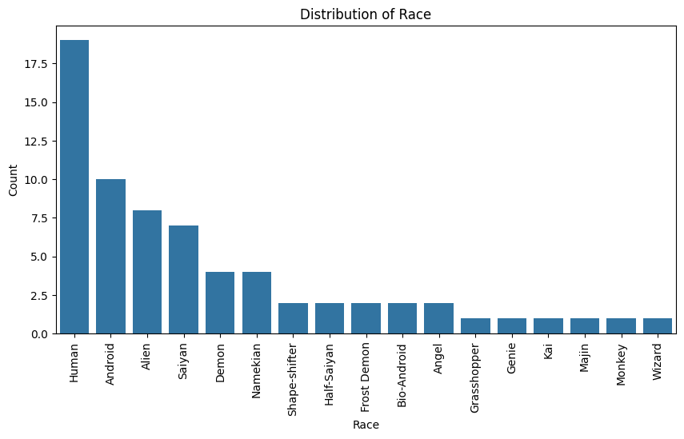

```python
# Create a count plot for categorical 'Race'
plt.figure(figsize=(10, 5))
sns.countplot(x=data['Race'], order=data['Race'].value_counts().index)  # Sort by frequency

# Rotate x-axis labels
plt.xticks(rotation=90)  # Rotate labels for better visibility
plt.title("Distribution of Race")
plt.xlabel("Race")
plt.ylabel("Count")
plt.show()
```

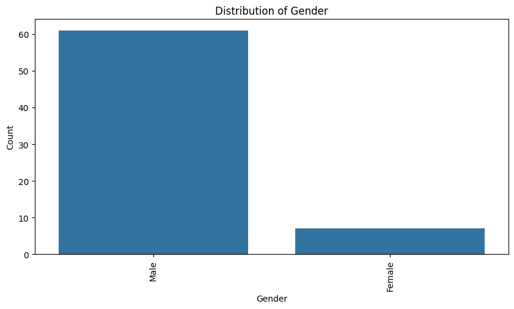

```python
# Create a count plot for categorical 'Race'
plt.figure(figsize=(10, 5))
sns.countplot(x=data['Gender'], order=data['Gender'].value_counts().index)  # Sort by frequency

# Rotate x-axis labels
plt.xticks(rotation=90)  # Rotate labels for better visibility
plt.title("Distribution of Gender")
plt.xlabel("Gender")
plt.ylabel("Count")
plt.show()
```

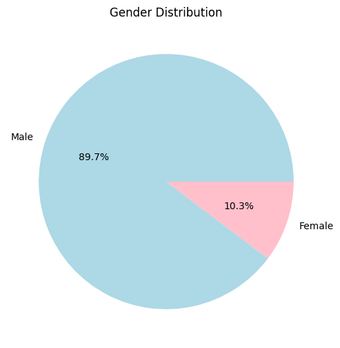

```python
data['Gender'].value_counts().plot.pie(autopct="%1.1f%%", colors=["lightblue", "pink"], figsize=(6, 6))
plt.title("Gender Distribution")
plt.ylabel("")  # Hide y-label
plt.show()
```

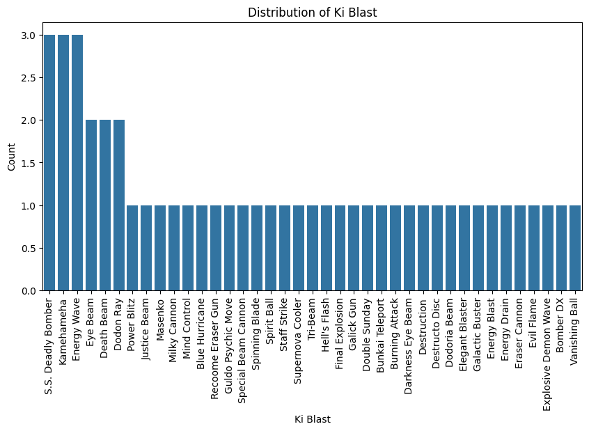

```python
# Create a count plot for categorical 'Race'
plt.figure(figsize=(10, 5))
sns.countplot(x=data['Ki Blast'], order=data['Ki Blast'].value_counts().index)  # Sort by frequency

# Rotate x-axis labels
plt.xticks(rotation=90)  # Rotate labels for better visibility
plt.title("Distribution of Ki Blast")
plt.xlabel("Ki Blast")
plt.ylabel("Count")
plt.show()
```

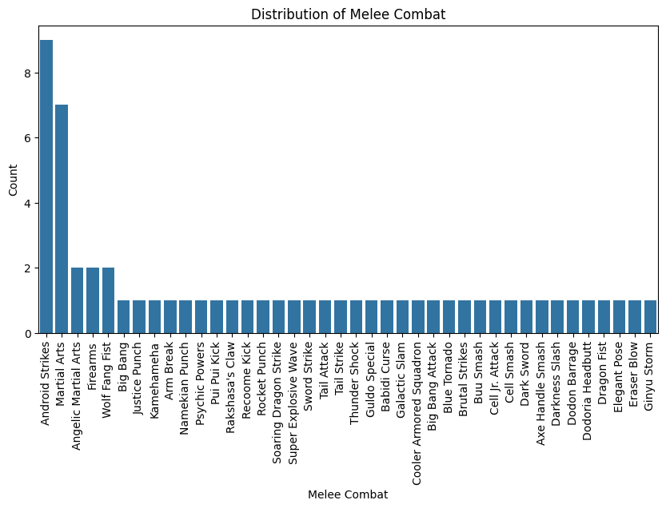

```python
# Create a count plot for categorical 'Race'
plt.figure(figsize=(10, 5))
sns.countplot(x=data['Melee Combat'], order=data['Melee Combat'].value_counts().index)  # Sort by frequency

# Rotate x-axis labels
plt.xticks(rotation=90)  # Rotate labels for better visibility
plt.title("Distribution of Melee Combat")
plt.xlabel("Melee Combat")
plt.ylabel("Count")
plt.show()
```

[figure not shown]

```python
# Create a count plot for categorical 'Race'
plt.figure(figsize=(10, 5))
sns.countplot(x=data['Melee Combat'], order=data['Melee Combat'].value_counts().index, hue = data['Race'])  # Sort by frequency

# Rotate x-axis labels
plt.xticks(rotation=90)  # Rotate labels for better visibility
plt.title("Distribution of Melee Combat")
plt.xlabel("Melee Combat")
plt.ylabel("Count")
plt.show()
```

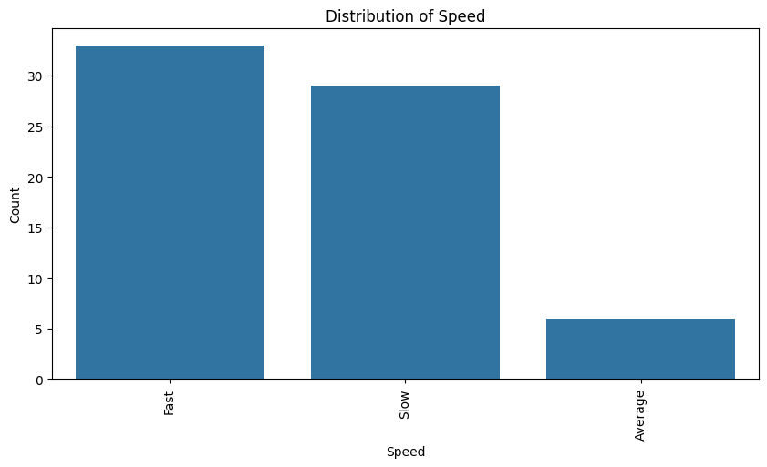

```python
# Create a count plot for categorical 'Race'
plt.figure(figsize=(10, 5))
sns.countplot(x=data['Speed'], order=data['Speed'].value_counts().index)  # Sort by frequency

# Rotate x-axis labels
plt.xticks(rotation=90)  # Rotate labels for better visibility
plt.title("Distribution of Speed")
plt.xlabel("Speed")
plt.ylabel("Count")
plt.show()
```

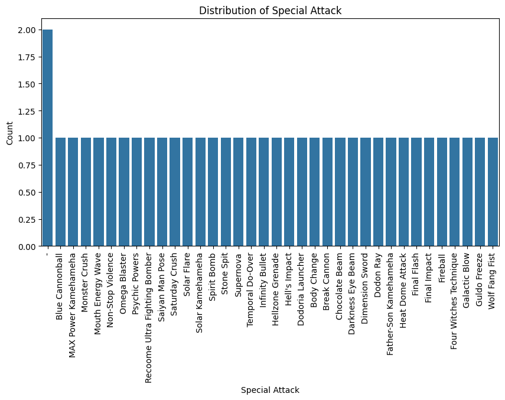

```python
# Create a count plot for categorical 'Race'
plt.figure(figsize=(10, 5))
sns.countplot(x=data['Special Attack'], order=data['Special Attack'].value_counts().index)  # Sort by frequency

# Rotate x-axis labels
plt.xticks(rotation=90)  # Rotate labels for better visibility
plt.title("Distribution of Special Attack")
plt.xlabel("Special Attack")
plt.ylabel("Count")
plt.show()
```

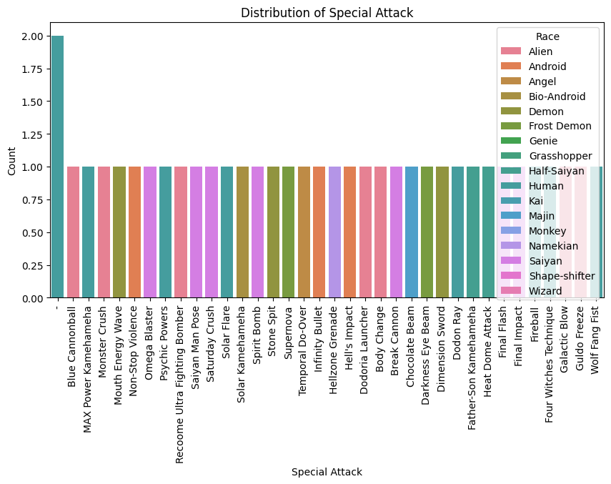

```python
# Create a count plot for categorical 'Race'
plt.figure(figsize=(10, 5))
sns.countplot(x=data['Special Attack'], order=data['Special Attack'].value_counts().index, hue = data['Race'])  # Sort by frequency

# Rotate x-axis labels
plt.xticks(rotation=90)  # Rotate labels for better visibility
plt.title("Distribution of Special Attack")
plt.xlabel("Special Attack")
plt.ylabel("Count")
plt.show()
```

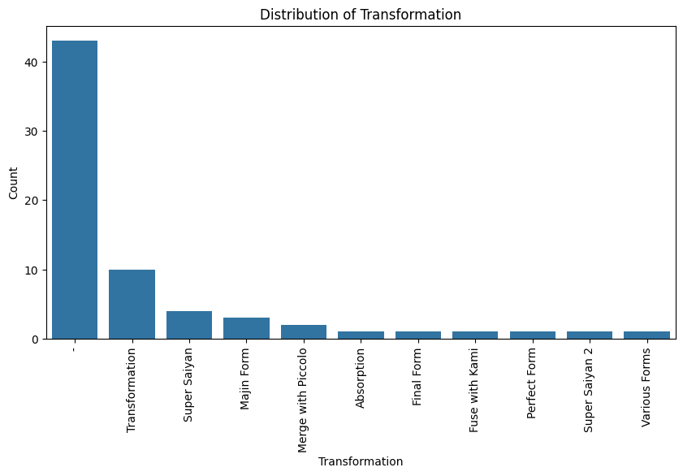

```python
# Create a count plot for categorical 'Race'
plt.figure(figsize=(10, 5))
sns.countplot(x=data['Transformation'], order=data['Transformation'].value_counts().index)  # Sort by frequency

# Rotate x-axis labels
plt.xticks(rotation=90)  # Rotate labels for better visibility
plt.title("Distribution of Transformation")
plt.xlabel("Transformation")
plt.ylabel("Count")
plt.show()
```

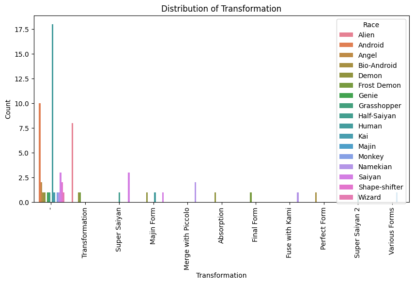

```python
# Create a count plot for categorical 'Race'
plt.figure(figsize=(10, 5))
sns.countplot(x=data['Transformation'], order=data['Transformation'].value_counts().index, hue = data['Race'])  # Sort by frequency

# Rotate x-axis labels
plt.xticks(rotation=90)  # Rotate labels for better visibility
plt.title("Distribution of Transformation")
plt.xlabel("Transformation")
plt.ylabel("Count")
plt.show()
```

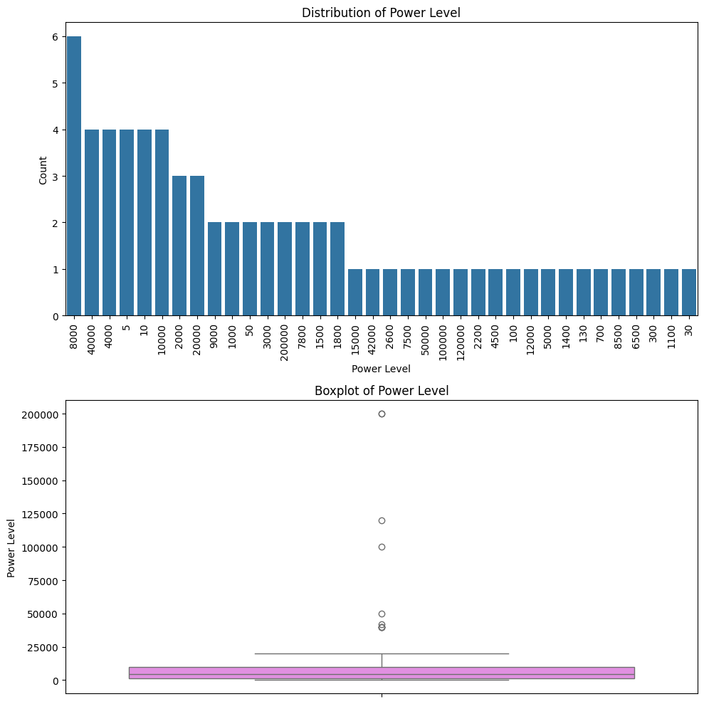

```python
fig, axes = plt.subplots(2, 1, figsize=(10, 10))

# Countplot (Top)
sns.countplot(x=data['Power Level'], order=data['Power Level'].value_counts().index, ax=axes[0])
axes[0].set_title("Distribution of Power Level")
axes[0].set_xlabel("Power Level")
axes[0].set_ylabel("Count")
axes[0].tick_params(axis='x', rotation=90)

# Boxplot (Bottom)
sns.boxplot(y=data['Power Level'], color='violet', ax=axes[1])
axes[1].set_title("Boxplot of Power Level")
axes[1].set_ylabel("Power Level")

plt.tight_layout()
plt.show()
```

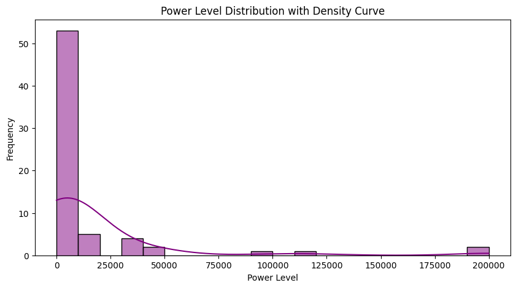

```python
plt.figure(figsize=(10, 5))
sns.histplot(data['Power Level'], kde=True, bins=20, color="purple")
plt.title("Power Level Distribution with Density Curve")
plt.xlabel("Power Level")
plt.ylabel("Frequency")
plt.show()
```

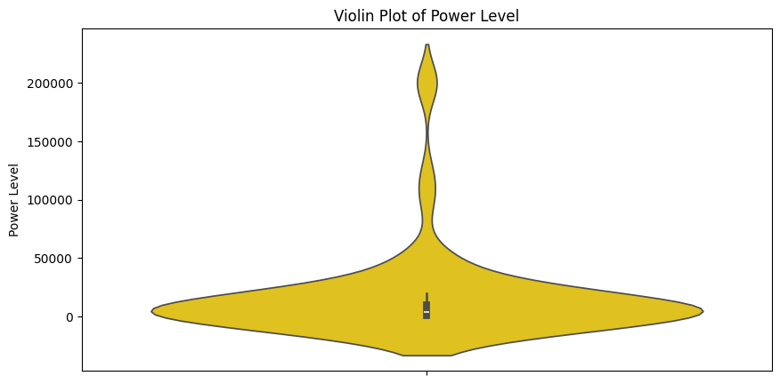

```python
plt.figure(figsize=(10, 5))
sns.violinplot(y=data['Power Level'], color="gold")
plt.title("Violin Plot of Power Level")
plt.ylabel("Power Level")
plt.show()
```

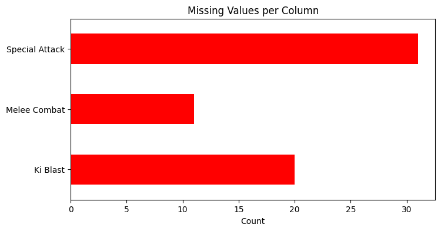

```python
missing = data.isnull().sum()
missing[missing > 0].plot(kind="barh", figsize=(8, 4), color="red")
plt.title("Missing Values per Column")
plt.xlabel("Count")
plt.show()
```

### Bivariate Analysis

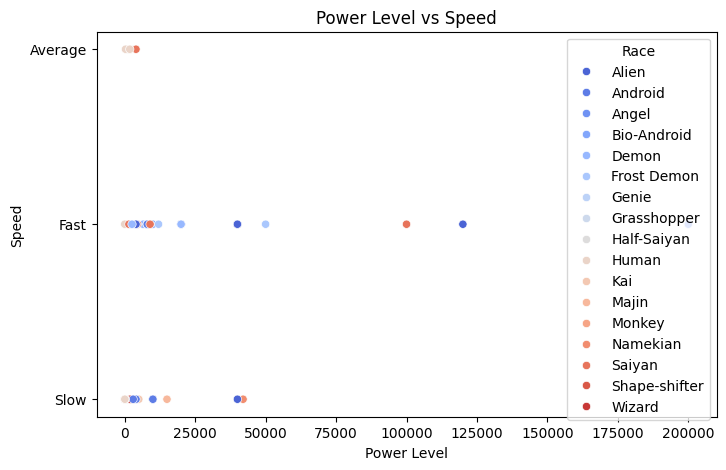

```python
plt.figure(figsize=(8, 5))
sns.scatterplot(x=data['Power Level'], y=data['Speed'], hue=data['Race'], palette="coolwarm")
plt.title("Power Level vs Speed")
plt.xlabel("Power Level")
plt.ylabel("Speed")
plt.show()
```

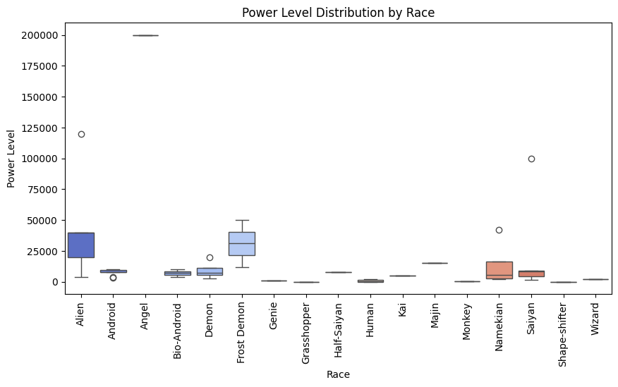

```python
plt.figure(figsize=(10, 5))
sns.boxplot(x=data['Race'], y=data['Power Level'], palette="coolwarm")
plt.xticks(rotation=90)
plt.title("Power Level Distribution by Race")
plt.show()
```

### Other Race and Transofmration Visuals

```python
data.groupby('Race')['Transformation'].apply(lambda x: ', '.join(x.unique())).reset_index()
```

|  | Race | Transformation |
| --- | --- | --- |
| 0 | Alien | Transformation |
| 1 | Android | - |
| 2 | Angel | - |
| 3 | Bio-Android | Perfect Form, - |
| 4 | Demon | Majin Form, Absorption, Transformation, - |
| 5 | Frost Demon | Final Form, Transformation |
| 6 | Genie | - |
| 7 | Grasshopper | - |
| 8 | Half-Saiyan | Super Saiyan 2, Super Saiyan |
| 9 | Human | -, Majin Form |
| 10 | Kai | - |
| 11 | Majin | Various Forms |
| 12 | Monkey | - |
| 13 | Namekian | Fuse with Kami, Merge with Piccolo, - |
| 14 | Saiyan | Super Saiyan, -, Majin Form |
| 15 | Shape-shifter | - |
| 16 | Wizard | - |

```python
data.groupby(['Race', 'Transformation']).size().unstack(fill_value=0)
```

| Transformation Race | - | Absorption | Final Form | Fuse with Kami | Majin Form | Merge with Piccolo | Perfect Form | Super Saiyan | Super Saiyan 2 | Transformation | Various Forms |
| --- | --- | --- | --- | --- | --- | --- | --- | --- | --- | --- | --- |
| Alien | 0 | 0 | 0 | 0 | 0 | 0 | 0 | 0 | 0 | 8 | 0 |
| Android | 10 | 0 | 0 | 0 | 0 | 0 | 0 | 0 | 0 | 0 | 0 |
| Angel | 2 | 0 | 0 | 0 | 0 | 0 | 0 | 0 | 0 | 0 | 0 |
| Bio-Android | 1 | 0 | 0 | 0 | 0 | 0 | 1 | 0 | 0 | 0 | 0 |
| Demon | 1 | 1 | 0 | 0 | 1 | 0 | 0 | 0 | 0 | 1 | 0 |
| Frost Demon | 0 | 0 | 1 | 0 | 0 | 0 | 0 | 0 | 0 | 1 | 0 |
| Genie | 1 | 0 | 0 | 0 | 0 | 0 | 0 | 0 | 0 | 0 | 0 |
| Grasshopper | 1 | 0 | 0 | 0 | 0 | 0 | 0 | 0 | 0 | 0 | 0 |
| Half-Saiyan | 0 | 0 | 0 | 0 | 0 | 0 | 0 | 1 | 1 | 0 | 0 |
| Human | 18 | 0 | 0 | 0 | 1 | 0 | 0 | 0 | 0 | 0 | 0 |
| Kai | 1 | 0 | 0 | 0 | 0 | 0 | 0 | 0 | 0 | 0 | 0 |
| Majin | 0 | 0 | 0 | 0 | 0 | 0 | 0 | 0 | 0 | 0 | 1 |
| Monkey | 1 | 0 | 0 | 0 | 0 | 0 | 0 | 0 | 0 | 0 | 0 |
| Namekian | 1 | 0 | 0 | 1 | 0 | 2 | 0 | 0 | 0 | 0 | 0 |
| Saiyan | 3 | 0 | 0 | 0 | 1 | 0 | 0 | 3 | 0 | 0 | 0 |
| Shape-shifter | 2 | 0 | 0 | 0 | 0 | 0 | 0 | 0 | 0 | 0 | 0 |
| Wizard | 1 | 0 | 0 | 0 | 0 | 0 | 0 | 0 | 0 | 0 | 0 |

```python
race_transformations = data.groupby('Race')['Transformation'].apply(lambda x: ', '.join(x.unique())).reset_index()
print(race_transformations)
```

```
             Race                             Transformation
0           Alien                             Transformation
1         Android                                          -
2           Angel                                          -
3     Bio-Android                            Perfect Form, -
4           Demon  Majin Form, Absorption, Transformation, -
5     Frost Demon                 Final Form, Transformation
6           Genie                                          -
7     Grasshopper                                          -
8     Half-Saiyan               Super Saiyan 2, Super Saiyan
9           Human                              -, Majin Form
10            Kai                                          -
11          Majin                              Various Forms
12         Monkey                                          -
13       Namekian      Fuse with Kami, Merge with Piccolo, -
14         Saiyan                Super Saiyan, -, Majin Form
15  Shape-shifter                                          -
16         Wizard                                          -
```

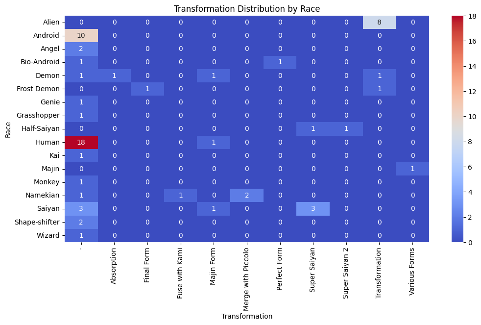

```python
# Ensure the transformation data is in a DataFrame
transformation_pivot = data.groupby(['Race', 'Transformation']).size().unstack(fill_value=0)

# Now plot the heatmap
plt.figure(figsize=(12,6))
sns.heatmap(transformation_pivot, cmap='coolwarm', annot=True, fmt='d')
plt.title("Transformation Distribution by Race")
plt.show()
```

Transformation by Race

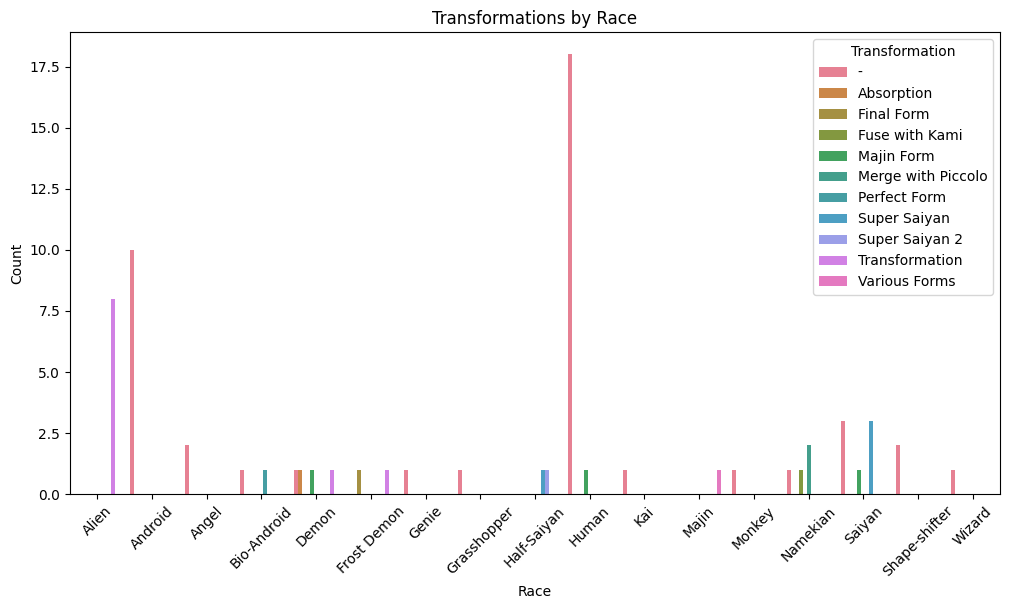

```python
plt.figure(figsize=(12, 6))
transformation_counts = data.groupby(['Race', 'Transformation']).size().reset_index(name='Count')
sns.barplot(data=transformation_counts, x='Race', y='Count', hue='Transformation')
plt.xticks(rotation=45)
plt.title("Transformations by Race")
plt.show()
```

```python
!pip install squarify
```

```
Downloading squarify-0.4.4-py3-none-any.whl (4.1 kB)
```

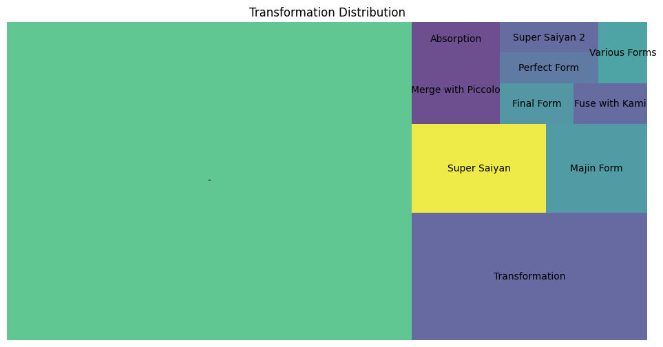

```python
import squarify

transformation_counts = data['Transformation'].value_counts()
plt.figure(figsize=(12,6))
squarify.plot(sizes=transformation_counts.values, label=transformation_counts.index, alpha=0.8)
plt.title("Transformation Distribution")
plt.axis('off')
plt.show()
```

Race to Transformation Flow

```python
from plotly import graph_objects as go

race_trans_counts = data.groupby(['Race', 'Transformation']).size().reset_index(name='Count')

fig = go.Figure(go.Sankey(
    node=dict(
        pad=15,
        thickness=20,
        label=list(race_trans_counts['Race'].unique()) + list(race_trans_counts['Transformation'].unique())
    ),
    link=dict(
        source=[list(race_trans_counts['Race'].unique()).index(r) for r in race_trans_counts['Race']],
        target=[list(race_trans_counts['Transformation'].unique()).index(t) + len(race_trans_counts['Race'].unique()) for t in race_trans_counts['Transformation']],
        value=race_trans_counts['Count']
    )
))

fig.update_layout(title_text="Race to Transformation Flow", font_size=12)
fig.show()
```

[interactive chart not shown]

## Data Preprocessing & Feature Engineering

Ordinal Encoding (Manual Mapping) Speed column

```python
print(data['Speed'].unique())
```

```
['Fast', 'Average', 'Slow']
Categories (3, object): ['Average', 'Fast', 'Slow']
```

```python
# Preserve original Speed column before encoding
data['Speed_Original'] = data['Speed']

# Apply ordinal encoding (manual mapping)
speed_mapping = {'Slow': 1, 'Average': 2, 'Fast': 3}

# Convert Speed column to string, remove spaces, map to numeric values while keeping NaNs
data['Speed'] = data['Speed'].astype(str).str.strip().map(speed_mapping)

# Check if all values converted properly, keeping NaNs
print(data[['Speed_Original', 'Speed']].head(10))
```

```
  Speed_Original  Speed
0           Fast      3
1           Fast      3
2           Fast      3
3           Fast      3
4           Fast      3
5        Average      2
6           Fast      3
7        Average      2
8           Slow      1
9           Slow      1
```

```python
data.head()
```

|  | Name | Race | Gender | Power Level | Ki Blast | Melee Combat | Speed | Special Attack | Transformation | Speed_Original |
| --- | --- | --- | --- | --- | --- | --- | --- | --- | --- | --- |
| 0 | Goku | Saiyan | Male | 9000 | Kamehameha | Dragon Fist | 3 | Spirit Bomb | Super Saiyan | Fast |
| 1 | Vegeta | Saiyan | Male | 8500 | Galick Gun | Big Bang | 3 | Final Flash | Super Saiyan | Fast |
| 2 | Piccolo | Namekian | Male | 8000 | Special Beam Cannon | Namekian Punch | 3 | Hellzone Grenade | Fuse with Kami | Fast |
| 3 | Gohan | Half-Saiyan | Male | 7500 | Masenko | Soaring Dragon Strike | 3 | Father-Son Kamehameha | Super Saiyan 2 | Fast |
| 4 | Future Trunks | Half-Saiyan | Male | 7800 | Burning Attack | Sword Strike | 3 | Heat Dome Attack | Super Saiyan | Fast |

```python
print(data['Speed'].unique())
```

```
[3 2 1]
```

Create a Power Score Rating Column

- Combination of Speed and Power Level

```python
print(data['Power Level'].unique())
```

```
[  9000   8500   8000   7500   7800   2000   2200   1800   1400      5
   1500  10000  12000  15000   1000   1100    300   6500     30    700
    130     10   3000   5000    100  42000   4500   4000  20000 120000
  40000 100000  50000     50   2600 200000]
```

```python
# Ensure Power Level is numeric
data['Power Level'] = pd.to_numeric(data['Power Level'], errors='coerce')

# Normalize Power Level to bring values to a 0-1 scale
data['Normalized_Power'] = (data['Power Level'] - data['Power Level'].min()) / (data['Power Level'].max() - data['Power Level'].min())
  # # scaled version of Power Level, ranging between 0 and 1.
  # ensures that all values are within a comparable range.
  # Used to balance calculations where raw Power Level values would be too large and dominate over other factors like Speed.

# Create Power Score (Weighted sum)
data['Power_Score'] = (data['Speed'] * 0.3) + (data['Normalized_Power'] * 0.7)
  # # raw strength metric
  # represents actual power without any modifications.
```

```python
print(data['Power_Score'].unique())
```

```
[0.93148329 0.92973324 0.9279832  0.92623316 0.92728318 0.60698267
 0.90768269 0.60628266 0.30488262 0.3        0.30523263 0.93498337
 0.94198355 0.35248381 0.30348259 0.6038326  0.60103253 0.92273307
 0.3000875  0.30243256 0.30043751 0.3000175  0.9        0.31048276
 0.31748294 0.30033251 0.30698267 0.44698617 0.91573289 0.90523263
 0.61398285 0.96998425 1.319993   1.039986   0.439986   0.91398285
 0.33498337 1.24999125 1.07498687 0.31398285 0.3001575  0.90908273
 1.6       ]
```

```python
data.head()
```

|  | Name | Race | Gender | Power Level | Ki Blast | Melee Combat | Speed | Special Attack | Transformation | Speed_Original | Normalized_Power | Power_Score |
| --- | --- | --- | --- | --- | --- | --- | --- | --- | --- | --- | --- | --- |
| 0 | Goku | Saiyan | Male | 9000 | Kamehameha | Dragon Fist | 3 | Spirit Bomb | Super Saiyan | Fast | 0.044976 | 0.931483 |
| 1 | Vegeta | Saiyan | Male | 8500 | Galick Gun | Big Bang | 3 | Final Flash | Super Saiyan | Fast | 0.042476 | 0.929733 |
| 2 | Piccolo | Namekian | Male | 8000 | Special Beam Cannon | Namekian Punch | 3 | Hellzone Grenade | Fuse with Kami | Fast | 0.039976 | 0.927983 |
| 3 | Gohan | Half-Saiyan | Male | 7500 | Masenko | Soaring Dragon Strike | 3 | Father-Son Kamehameha | Super Saiyan 2 | Fast | 0.037476 | 0.926233 |
| 4 | Future Trunks | Half-Saiyan | Male | 7800 | Burning Attack | Sword Strike | 3 | Heat Dome Attack | Super Saiyan | Fast | 0.038976 | 0.927283 |

Create meta column called Meta

```python
# Convert categorical columns to string before concatenation
data['Meta'] = data['Name'].astype(str) + ' ' + \
               data['Race'].astype(str) + ' ' + \
               data['Ki Blast'].astype(str) + ' ' + \
               data['Melee Combat'].astype(str) + ' ' + \
               data['Special Attack'].astype(str) + ' ' + \
               data['Transformation'].astype(str) + ' ' + \
               data['Gender'].astype(str)
```

```python
data.head()
```

|  | Name | Race | Gender | Power Level | Ki Blast | Melee Combat | Speed | Special Attack | Transformation | Speed_Original | Normalized_Power | Power_Score | Meta |
| --- | --- | --- | --- | --- | --- | --- | --- | --- | --- | --- | --- | --- | --- |
| 0 | Goku | Saiyan | Male | 9000 | Kamehameha | Dragon Fist | 3 | Spirit Bomb | Super Saiyan | Fast | 0.044976 | 0.931483 | Goku Saiyan Kamehameha Dragon Fist Spirit Bomb... |
| 1 | Vegeta | Saiyan | Male | 8500 | Galick Gun | Big Bang | 3 | Final Flash | Super Saiyan | Fast | 0.042476 | 0.929733 | Vegeta Saiyan Galick Gun Big Bang Final Flash ... |
| 2 | Piccolo | Namekian | Male | 8000 | Special Beam Cannon | Namekian Punch | 3 | Hellzone Grenade | Fuse with Kami | Fast | 0.039976 | 0.927983 | Piccolo Namekian Special Beam Cannon Namekian ... |
| 3 | Gohan | Half-Saiyan | Male | 7500 | Masenko | Soaring Dragon Strike | 3 | Father-Son Kamehameha | Super Saiyan 2 | Fast | 0.037476 | 0.926233 | Gohan Half-Saiyan Masenko Soaring Dragon Strik... |
| 4 | Future Trunks | Half-Saiyan | Male | 7800 | Burning Attack | Sword Strike | 3 | Heat Dome Attack | Super Saiyan | Fast | 0.038976 | 0.927283 | Future Trunks Half-Saiyan Burning Attack Sword... |

```python
data.info()
```

```
<class 'pandas.core.frame.DataFrame'>
Index: 68 entries, 0 to 69
Data columns (total 13 columns):
 #   Column            Non-Null Count  Dtype
---  ------            --------------  -----
 0   Name              68 non-null     category
 1   Race              68 non-null     category
 2   Gender            68 non-null     category
 3   Power Level       68 non-null     int64
 4   Ki Blast          48 non-null     category
 5   Melee Combat      57 non-null     category
 6   Speed             68 non-null     int64
 7   Special Attack    37 non-null     category
 8   Transformation    68 non-null     category
 9   Speed_Original    68 non-null     category
 10  Normalized_Power  68 non-null     float64
 11  Power_Score       68 non-null     float64
 12  Meta              68 non-null     object
dtypes: category(8), float64(2), int64(2), object(1)
memory usage: 11.6+ KB
```

```python
data.shape
```

```
(68, 13)
```

```python
data.duplicated().sum()
```

```
0
```

```python
data.head(1)
```

|  | Name | Race | Gender | Power Level | Ki Blast | Melee Combat | Speed | Special Attack | Transformation | Speed_Original | Normalized_Power | Power_Score | Meta |
| --- | --- | --- | --- | --- | --- | --- | --- | --- | --- | --- | --- | --- | --- |
| 0 | Goku | Saiyan | Male | 9000 | Kamehameha | Dragon Fist | 3 | Spirit Bomb | Super Saiyan | Fast | 0.044976 | 0.931483 | Goku Saiyan Kamehameha Dragon Fist Spirit Bomb... |

```python
data.select_dtypes(include=['category', 'object']).columns.to_list()
```

```
['Name',
 'Race',
 'Gender',
 'Ki Blast',
 'Melee Combat',
 'Special Attack',
 'Transformation',
 'Speed_Original',
 'Meta']
```

Chnage Decimal Places

```python
data[['Normalized_Power','Power_Score']] = data[['Normalized_Power','Power_Score']].round(2)
```

```python
data.head()
```

|  | Name | Race | Gender | Power Level | Ki Blast | Melee Combat | Speed | Special Attack | Transformation | Speed_Original | Normalized_Power | Power_Score | Meta |
| --- | --- | --- | --- | --- | --- | --- | --- | --- | --- | --- | --- | --- | --- |
| 0 | Goku | Saiyan | Male | 9000 | Kamehameha | Dragon Fist | 3 | Spirit Bomb | Super Saiyan | Fast | 0.04 | 0.93 | Goku Saiyan Kamehameha Dragon Fist Spirit Bomb... |
| 1 | Vegeta | Saiyan | Male | 8500 | Galick Gun | Big Bang | 3 | Final Flash | Super Saiyan | Fast | 0.04 | 0.93 | Vegeta Saiyan Galick Gun Big Bang Final Flash ... |
| 2 | Piccolo | Namekian | Male | 8000 | Special Beam Cannon | Namekian Punch | 3 | Hellzone Grenade | Fuse with Kami | Fast | 0.04 | 0.93 | Piccolo Namekian Special Beam Cannon Namekian ... |
| 3 | Gohan | Half-Saiyan | Male | 7500 | Masenko | Soaring Dragon Strike | 3 | Father-Son Kamehameha | Super Saiyan 2 | Fast | 0.04 | 0.93 | Gohan Half-Saiyan Masenko Soaring Dragon Strik... |
| 4 | Future Trunks | Half-Saiyan | Male | 7800 | Burning Attack | Sword Strike | 3 | Heat Dome Attack | Super Saiyan | Fast | 0.04 | 0.93 | Future Trunks Half-Saiyan Burning Attack Sword... |

Transform Count by Race

```python
data.groupby('Race')['Transformation'].transform('count')
```

|  | Transformation |
| --- | --- |
| 0 | 7 |
| 1 | 7 |
| 2 | 4 |
| 3 | 2 |
| 4 | 2 |
| ... | ... |
| 65 | 19 |
| 66 | 19 |
| 67 | 19 |
| 68 | 2 |
| 69 | 2 |

68 rows × 1 columns

**dtype:** int64

Top 10 Names by Speed

```python
data[['Name', 'Speed']].sort_values(by='Speed', ascending=False).head(10)
```

|  | Name | Speed |
| --- | --- | --- |
| 0 | Goku | 3 |
| 25 | Launch | 3 |
| 1 | Vegeta | 3 |
| 37 | Zarbon | 3 |
| 38 | Dodoria | 3 |
| 39 | Captain Ginyu | 3 |
| 40 | Burter | 3 |
| 41 | Recoome | 3 |
| 43 | Cell Jr. | 3 |
| 48 | Yakon | 3 |

```python
data[['Name', 'Power Level']].sort_values(by='Power Level', ascending=False).head(10)
```

|  | Name | Power Level |
| --- | --- | --- |
| 69 | Whis | 200000 |
| 68 | Vados | 200000 |
| 39 | Captain Ginyu | 120000 |
| 53 | Broly | 100000 |
| 54 | Cooler | 50000 |
| 32 | Nail | 42000 |
| 42 | Guldo | 40000 |
| 51 | Bojack | 40000 |
| 40 | Burter | 40000 |
| 41 | Recoome | 40000 |

```python
data[['Name', 'Normalized_Power']].sort_values(by='Normalized_Power', ascending=False).head(10)
```

|  | Name | Normalized_Power |
| --- | --- | --- |
| 69 | Whis | 1.00 |
| 68 | Vados | 1.00 |
| 39 | Captain Ginyu | 0.60 |
| 53 | Broly | 0.50 |
| 54 | Cooler | 0.25 |
| 32 | Nail | 0.21 |
| 51 | Bojack | 0.20 |
| 40 | Burter | 0.20 |
| 41 | Recoome | 0.20 |
| 42 | Guldo | 0.20 |

Top 10 Named by Power_Score

```python
data[['Name', 'Power_Score']].sort_values(by='Power_Score', ascending=False).head(10)
```

|  | Name | Power_Score |
| --- | --- | --- |
| 69 | Whis | 1.60 |
| 68 | Vados | 1.60 |
| 39 | Captain Ginyu | 1.32 |
| 53 | Broly | 1.25 |
| 54 | Cooler | 1.07 |
| 40 | Burter | 1.04 |
| 41 | Recoome | 1.04 |
| 51 | Bojack | 1.04 |
| 52 | Janemba | 0.97 |
| 38 | Dodoria | 0.97 |

```python
data[data['Name'] == 'Goku']
```

|  | Name | Race | Gender | Power Level | Ki Blast | Melee Combat | Speed | Special Attack | Transformation | Speed_Original | Normalized_Power | Power_Score | Meta |
| --- | --- | --- | --- | --- | --- | --- | --- | --- | --- | --- | --- | --- | --- |
| 0 | Goku | Saiyan | Male | 9000 | Kamehameha | Dragon Fist | 3 | Spirit Bomb | Super Saiyan | Fast | 0.04 | 0.93 | Goku Saiyan Kamehameha Dragon Fist Spirit Bomb... |

- Goku should be one of the most powerful beings in Dragon Ball
- This Transformation of Goku is not at his peak power level

## Conclusion and Recommendations

Conclusion

- The exploratory data analysis (EDA) of the Dragon Ball dataset revealed key insights into character attributes, power levels, and rankings. The dataset contained various character traits such as race, power level, transformations, melee combat abilities, ki blasts, and speed, which were essential for understanding character strengths.

## Recommendations for Future Data Science Projects

This dataset provides a great foundation for various machine learning applications, including supervised, unsupervised, and reinforcement learning techniques.

Supervised Learning Projects

- Regression Analysis
  - Predict Power Levels based on race, experience, and transformations.
  - Estimate Battle Outcomes using combat attributes.
- Classification Models
  - Battle Winner Prediction: Use logistic regression, decision trees, or neural networks to predict battle outcomes.
  - Transformation Recommendation: Given a character’s stats, suggest the best transformation.

Unsupervised Learning Projects

- Character Clustering
  - Use K-Means or DBSCAN to group characters by fighting style, power, or transformation types.
  - Discover hidden archetypes, such as Tactical Fighters vs. Energy Blasters.
- Anomaly Detection
  - Identify outliers in power levels or transformations.
  - Detect characters with extremely high battle efficiency compared to their peers.

Deep Learning Applications

- Anime Scene Classification
  - Train a Convolutional Neural Network (CNN) to classify Dragon Ball fight scenes vs. non-fight scenes.
  - Use transfer learning (VGG16, ResNet) to automate scene detection.
- Text-based Analysis
  - Use NLP models (BERT, GPT) to analyze Dragon Ball dialogues, detecting sentiment or key themes.

Time Series and Forecasting

- Power Growth Over Time
  - Model how characters’ power levels evolve over different sagas using time series forecasting. Predict the next transformation or power spike based on past battles.
- Battle Duration Prediction
  - Given a fight scenario, predict how long the battle will last.

Recommendation Systems

- Binary Classification Recommender
  - "Should a character learn a technique (e.g., Kamehameha, Final Flash)?"
  - Use collaborative filtering with a binary classifier.
- Multi-Class Recommendation
  - "Which transformation is best for a fighter?"
  - Recommend SSJ, SSJ2, SSJ3, Ultra Instinct, etc. based on attributes.
- Regression-Based Recommender
  - Predict how many battles a character needs before unlocking a transformation.

## Save New dataframe as Data

```python
data.to_csv('/content/drive/MyDrive/My DS DA/Dragon Ball Z/data.csv', index = False)
```

```python
data.head()
```

|  | Name | Race | Gender | Power Level | Ki Blast | Melee Combat | Speed | Special Attack | Transformation | Speed_Original | Normalized_Power | Power_Score | Meta |
| --- | --- | --- | --- | --- | --- | --- | --- | --- | --- | --- | --- | --- | --- |
| 0 | Goku | Saiyan | Male | 9000 | Kamehameha | Dragon Fist | 3 | Spirit Bomb | Super Saiyan | Fast | 0.04 | 0.93 | Goku Saiyan Kamehameha Dragon Fist Spirit Bomb... |
| 1 | Vegeta | Saiyan | Male | 8500 | Galick Gun | Big Bang | 3 | Final Flash | Super Saiyan | Fast | 0.04 | 0.93 | Vegeta Saiyan Galick Gun Big Bang Final Flash ... |
| 2 | Piccolo | Namekian | Male | 8000 | Special Beam Cannon | Namekian Punch | 3 | Hellzone Grenade | Fuse with Kami | Fast | 0.04 | 0.93 | Piccolo Namekian Special Beam Cannon Namekian ... |
| 3 | Gohan | Half-Saiyan | Male | 7500 | Masenko | Soaring Dragon Strike | 3 | Father-Son Kamehameha | Super Saiyan 2 | Fast | 0.04 | 0.93 | Gohan Half-Saiyan Masenko Soaring Dragon Strik... |
| 4 | Future Trunks | Half-Saiyan | Male | 7800 | Burning Attack | Sword Strike | 3 | Heat Dome Attack | Super Saiyan | Fast | 0.04 | 0.93 | Future Trunks Half-Saiyan Burning Attack Sword... |

```python
# # google

# path_ipynb = '/content/drive/MyDrive/My DS DA/Dragon Ball Z/1 EDA.ipynb'
# notebook_path = path_ipynb

# !jupyter nbconvert --to html "{notebook_path}"

# from google.colab import files
# path_html = '/content/drive/MyDrive/My DS DA/Dragon Ball Z/1 EDA.html'

# files.download(path_html)
```